# Project: Investigate a Dataset - Tmdb-Movies Dataset

- Introduction
- Data Wrangling
- Exploratory Data Analysis
- Conclusions

## Introduction

### Dataset Description

> : This is a dataset containing 10,000 movies, collated from 1960 - 2015. Collected from The Movie Database, it contains 21 columns . They are,
> - the ID column - containing unique identifiers for each individual movie entry,
> - Imdb Id - containing identifiers for each movie's result on Imdb,
> - popularity - of each movie given a numerical value,
> - budget - the budget for each movie,
> - revenue - the revenue for each movie upon release,
> - original_title - the title of each individual movie,
> - cast - the main cast of each movie,
> - homepage - the link to each movie's release website,
> - director - the director of each movie,
> - tagline - the tagline or slogan given to each movie on release,
> - keywords - the combination of keywords found in the movie,
> - overview - an overview of the movie's description in string literal,
> - runtime - the entire length of each movie in minutes,
> - genres - the genre or genres under which each movie was released,
> - production_companies - the company behind each movie,
> - release_date - the date each movie was released,
> - vote_count,
> - vote_average,
> - release_year- the year in which each movie was released,
> - budget_adj - the budget of each movie adjusted for inflation in 2010 dollars,
> - revenue_adj - the revenue of each movie adjusted for inflation in 2010 dollars

### Question(s) for Analysis

> Which Genres are the most popular from year to year? What kind of properties are associated with movies that have high revenue?

```python
# We import modules for use
import pandas as pd
import numpy as np
import ast
import matplotlib.pyplot as plt
import seaborn as sns
%matplotlib inline
```

```python
# Upgrade pandas to use dataframe.explode() function.
!pip install --upgrade pandas==0.25.0
```

[output not shown]

## Data Wrangling

### General Properties

> Here, we need to read in our data from a csv file containing the table for analysis. Our file is separated by a comma delimiter, so we do not need to specify a separator type. Afterwards, we inspect the data that has been read in by getting some info, some summary statistics and determining the shape and size of our data. This information will be useful in cleaning our data.

```python
# Load your data and print out a few lines. Perform operations to inspect data
#   types and look for instances of missing or possibly errant data.
df = pd.read_csv('tmdb-movies.csv')
df.head()
```

|  | id | imdb_id | popularity | budget | revenue | original_title | cast | homepage | director | tagline | ... | overview | runtime | genres | production_companies | release_date | vote_count | vote_average | release_year | budget_adj | revenue_adj |
| --- | --- | --- | --- | --- | --- | --- | --- | --- | --- | --- | --- | --- | --- | --- | --- | --- | --- | --- | --- | --- | --- |
| 0 | 135397 | tt0369610 | 32.985763 | 150000000 | 1513528810 | Jurassic World | Chris Pratt\|Bryce Dallas Howard\|Irrfan Khan\|Vi... | http://www.jurassicworld.com/ | Colin Trevorrow | The park is open. | ... | Twenty-two years after the events of Jurassic ... | 124 | Action\|Adventure\|Science Fiction\|Thriller | Universal Studios\|Amblin Entertainment\|Legenda... | 6/9/15 | 5562 | 6.5 | 2015 | 1.379999e+08 | 1.392446e+09 |
| 1 | 76341 | tt1392190 | 28.419936 | 150000000 | 378436354 | Mad Max: Fury Road | Tom Hardy\|Charlize Theron\|Hugh Keays-Byrne\|Nic... | http://www.madmaxmovie.com/ | George Miller | What a Lovely Day. | ... | An apocalyptic story set in the furthest reach... | 120 | Action\|Adventure\|Science Fiction\|Thriller | Village Roadshow Pictures\|Kennedy Miller Produ... | 5/13/15 | 6185 | 7.1 | 2015 | 1.379999e+08 | 3.481613e+08 |
| 2 | 262500 | tt2908446 | 13.112507 | 110000000 | 295238201 | Insurgent | Shailene Woodley\|Theo James\|Kate Winslet\|Ansel... | http://www.thedivergentseries.movie/#insurgent | Robert Schwentke | One Choice Can Destroy You | ... | Beatrice Prior must confront her inner demons ... | 119 | Adventure\|Science Fiction\|Thriller | Summit Entertainment\|Mandeville Films\|Red Wago... | 3/18/15 | 2480 | 6.3 | 2015 | 1.012000e+08 | 2.716190e+08 |
| 3 | 140607 | tt2488496 | 11.173104 | 200000000 | 2068178225 | Star Wars: The Force Awakens | Harrison Ford\|Mark Hamill\|Carrie Fisher\|Adam D... | http://www.starwars.com/films/star-wars-episod... | J.J. Abrams | Every generation has a story. | ... | Thirty years after defeating the Galactic Empi... | 136 | Action\|Adventure\|Science Fiction\|Fantasy | Lucasfilm\|Truenorth Productions\|Bad Robot | 12/15/15 | 5292 | 7.5 | 2015 | 1.839999e+08 | 1.902723e+09 |
| 4 | 168259 | tt2820852 | 9.335014 | 190000000 | 1506249360 | Furious 7 | Vin Diesel\|Paul Walker\|Jason Statham\|Michelle ... | http://www.furious7.com/ | James Wan | Vengeance Hits Home | ... | Deckard Shaw seeks revenge against Dominic Tor... | 137 | Action\|Crime\|Thriller | Universal Pictures\|Original Film\|Media Rights ... | 4/1/15 | 2947 | 7.3 | 2015 | 1.747999e+08 | 1.385749e+09 |

5 rows × 21 columns

```python
# Check through to determine how many empty values there are in the dataset
df.info()
```

```
<class 'pandas.core.frame.DataFrame'>
RangeIndex: 10866 entries, 0 to 10865
Data columns (total 21 columns):
id                      10866 non-null int64
imdb_id                 10856 non-null object
popularity              10866 non-null float64
budget                  10866 non-null int64
revenue                 10866 non-null int64
original_title          10866 non-null object
cast                    10790 non-null object
homepage                2936 non-null object
director                10822 non-null object
tagline                 8042 non-null object
keywords                9373 non-null object
overview                10862 non-null object
runtime                 10866 non-null int64
genres                  10843 non-null object
production_companies    9836 non-null object
release_date            10866 non-null object
vote_count              10866 non-null int64
vote_average            10866 non-null float64
release_year            10866 non-null int64
budget_adj              10866 non-null float64
revenue_adj             10866 non-null float64
dtypes: float64(4), int64(6), object(11)
memory usage: 1.7+ MB
```

```python
# Determine number of rows and columns
df.shape
```

```
(10866, 21)
```

```python
# Summary statistics
df.describe()
```

|  | id | popularity | budget | revenue | runtime | vote_count | vote_average | release_year | budget_adj | revenue_adj |
| --- | --- | --- | --- | --- | --- | --- | --- | --- | --- | --- |
| count | 10866.000000 | 10866.000000 | 1.086600e+04 | 1.086600e+04 | 10866.000000 | 10866.000000 | 10866.000000 | 10866.000000 | 1.086600e+04 | 1.086600e+04 |
| mean | 66064.177434 | 0.646441 | 1.462570e+07 | 3.982332e+07 | 102.070863 | 217.389748 | 5.974922 | 2001.322658 | 1.755104e+07 | 5.136436e+07 |
| std | 92130.136561 | 1.000185 | 3.091321e+07 | 1.170035e+08 | 31.381405 | 575.619058 | 0.935142 | 12.812941 | 3.430616e+07 | 1.446325e+08 |
| min | 5.000000 | 0.000065 | 0.000000e+00 | 0.000000e+00 | 0.000000 | 10.000000 | 1.500000 | 1960.000000 | 0.000000e+00 | 0.000000e+00 |
| 25% | 10596.250000 | 0.207583 | 0.000000e+00 | 0.000000e+00 | 90.000000 | 17.000000 | 5.400000 | 1995.000000 | 0.000000e+00 | 0.000000e+00 |
| 50% | 20669.000000 | 0.383856 | 0.000000e+00 | 0.000000e+00 | 99.000000 | 38.000000 | 6.000000 | 2006.000000 | 0.000000e+00 | 0.000000e+00 |
| 75% | 75610.000000 | 0.713817 | 1.500000e+07 | 2.400000e+07 | 111.000000 | 145.750000 | 6.600000 | 2011.000000 | 2.085325e+07 | 3.369710e+07 |
| max | 417859.000000 | 32.985763 | 4.250000e+08 | 2.781506e+09 | 900.000000 | 9767.000000 | 9.200000 | 2015.000000 | 4.250000e+08 | 2.827124e+09 |

> To begin our data cleaning process, we first take a look at how many empty rows there are in our data, then the number of duplicates, and finally the number of unique values.

```python
# Return sum of null values in dataset
df.isna().sum()
```

```
id                         0
imdb_id                   10
popularity                 0
budget                     0
revenue                    0
original_title             0
cast                      76
homepage                7930
director                  44
tagline                 2824
keywords                1493
overview                   4
runtime                    0
genres                    23
production_companies    1030
release_date               0
vote_count                 0
vote_average               0
release_year               0
budget_adj                 0
revenue_adj                0
dtype: int64
```

```python
# Sum of duplicates
df.duplicated().sum()
```

```
1
```

```python
df.nunique()
```

```
id                      10865
imdb_id                 10855
popularity              10814
budget                    557
revenue                  4702
original_title          10571
cast                    10719
homepage                 2896
director                 5067
tagline                  7997
keywords                 8804
overview                10847
runtime                   247
genres                   2039
production_companies     7445
release_date             5909
vote_count               1289
vote_average               72
release_year               56
budget_adj               2614
revenue_adj              4840
dtype: int64
```

### Data Cleaning

> After determining the columns useful to our analysis, those that are not integral to our research questions are dropped. Afterwards, missing values and duplicates are dropped from the rows.

### Drop Extraneous Columns

```python
# Dropping columns not to be used for analysis
df.drop(['cast', 'homepage', 'imdb_id', 'keywords', 'overview', 'tagline', 'vote_count', 'vote_average', 'revenue', 'budget', 'release_date', 'original_title'], axis = 1, inplace = True)
```

```python
# Checking to see if columns have been dropped
df.head()
```

|  | id | popularity | director | runtime | genres | production_companies | release_year | budget_adj | revenue_adj |
| --- | --- | --- | --- | --- | --- | --- | --- | --- | --- |
| 0 | 135397 | 32.985763 | Colin Trevorrow | 124 | Action\|Adventure\|Science Fiction\|Thriller | Universal Studios\|Amblin Entertainment\|Legenda... | 2015 | 1.379999e+08 | 1.392446e+09 |
| 1 | 76341 | 28.419936 | George Miller | 120 | Action\|Adventure\|Science Fiction\|Thriller | Village Roadshow Pictures\|Kennedy Miller Produ... | 2015 | 1.379999e+08 | 3.481613e+08 |
| 2 | 262500 | 13.112507 | Robert Schwentke | 119 | Adventure\|Science Fiction\|Thriller | Summit Entertainment\|Mandeville Films\|Red Wago... | 2015 | 1.012000e+08 | 2.716190e+08 |
| 3 | 140607 | 11.173104 | J.J. Abrams | 136 | Action\|Adventure\|Science Fiction\|Fantasy | Lucasfilm\|Truenorth Productions\|Bad Robot | 2015 | 1.839999e+08 | 1.902723e+09 |
| 4 | 168259 | 9.335014 | James Wan | 137 | Action\|Crime\|Thriller | Universal Pictures\|Original Film\|Media Rights ... | 2015 | 1.747999e+08 | 1.385749e+09 |

```python
# Drop empty rows
df.dropna(inplace = True)
```

```python
# Check to see if empty rows have been trimmed
df.shape
```

```
(9807, 9)
```

```python
# Drop duplicate values in dataset
df.drop_duplicates(inplace = True)
```

```python
df.head()
```

|  | id | popularity | director | runtime | genres | production_companies | release_year | budget_adj | revenue_adj |
| --- | --- | --- | --- | --- | --- | --- | --- | --- | --- |
| 0 | 135397 | 32.985763 | Colin Trevorrow | 124 | Action\|Adventure\|Science Fiction\|Thriller | Universal Studios\|Amblin Entertainment\|Legenda... | 2015 | 1.379999e+08 | 1.392446e+09 |
| 1 | 76341 | 28.419936 | George Miller | 120 | Action\|Adventure\|Science Fiction\|Thriller | Village Roadshow Pictures\|Kennedy Miller Produ... | 2015 | 1.379999e+08 | 3.481613e+08 |
| 2 | 262500 | 13.112507 | Robert Schwentke | 119 | Adventure\|Science Fiction\|Thriller | Summit Entertainment\|Mandeville Films\|Red Wago... | 2015 | 1.012000e+08 | 2.716190e+08 |
| 3 | 140607 | 11.173104 | J.J. Abrams | 136 | Action\|Adventure\|Science Fiction\|Fantasy | Lucasfilm\|Truenorth Productions\|Bad Robot | 2015 | 1.839999e+08 | 1.902723e+09 |
| 4 | 168259 | 9.335014 | James Wan | 137 | Action\|Crime\|Thriller | Universal Pictures\|Original Film\|Media Rights ... | 2015 | 1.747999e+08 | 1.385749e+09 |

> Our Genres column contains multiple genres for each movie, we can then split the genres column, and convert the column from a string to a list containing the genres pertaining to each movie, in order for analysis to be easier.

```python
# columns to split by "/"
split_columns = ['genres']

# apply split function to each column of each dataframe copy
for c in split_columns:
    df[c] = df[c].apply(lambda x: x.split("|"))
```

```python
df.head()
```

|  | id | popularity | director | runtime | genres | production_companies | release_year | budget_adj | revenue_adj |
| --- | --- | --- | --- | --- | --- | --- | --- | --- | --- |
| 0 | 135397 | 32.985763 | Colin Trevorrow | 124 | [Action, Adventure, Science Fiction, Thriller] | Universal Studios\|Amblin Entertainment\|Legenda... | 2015 | 1.379999e+08 | 1.392446e+09 |
| 1 | 76341 | 28.419936 | George Miller | 120 | [Action, Adventure, Science Fiction, Thriller] | Village Roadshow Pictures\|Kennedy Miller Produ... | 2015 | 1.379999e+08 | 3.481613e+08 |
| 2 | 262500 | 13.112507 | Robert Schwentke | 119 | [Adventure, Science Fiction, Thriller] | Summit Entertainment\|Mandeville Films\|Red Wago... | 2015 | 1.012000e+08 | 2.716190e+08 |
| 3 | 140607 | 11.173104 | J.J. Abrams | 136 | [Action, Adventure, Science Fiction, Fantasy] | Lucasfilm\|Truenorth Productions\|Bad Robot | 2015 | 1.839999e+08 | 1.902723e+09 |
| 4 | 168259 | 9.335014 | James Wan | 137 | [Action, Crime, Thriller] | Universal Pictures\|Original Film\|Media Rights ... | 2015 | 1.747999e+08 | 1.385749e+09 |

> Now that our data has been properly cleaned, and unused columns have been dropped, missing values and duplicate values have been removed, it's time to anwer the research questions.

## Exploratory Data Analysis

```python
# To begin exploring our data, we groupby release year first
popularity_mean = df.groupby(['release_year']).popularity.mean()
popularity_mean.head()
```

```
release_year
1960    0.458932
1961    0.430438
1962    0.465245
1963    0.502706
1964    0.421091
Name: popularity, dtype: float64
```

```python
# We then look at the summary statistics
popularity_mean.describe()
```

```
count    56.000000
mean      0.588379
std       0.147449
min       0.308457
25%       0.486578
50%       0.572578
75%       0.674149
max       1.135148
Name: popularity, dtype: float64
```

> From our summary statistics, we can see that the max mean popularity is quite high compared to other values, this could be due to improperly inputted values. To continue our analysis, we'll look at a visualization of our data.

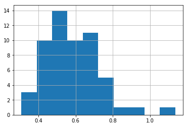

```python
# Popularity visualized
popularity_mean.hist()
```

```python
from collections import Counter

# Because the genres for every movie are basically sets
# We can use a "flattened list" approach for this question
flattened_genres = [elem for sublist in df['genres'] for elem in sublist]
fav_genre = Counter(flattened_genres).most_common()

# retrieving top 5 genres
fav_genre[:5]
```

```
[('Drama', 4369),
 ('Comedy', 3438),
 ('Thriller', 2747),
 ('Action', 2235),
 ('Romance', 1570)]
```